# Bowling

Sidharth Gupta

The original bowling model is simple we get 2 frames in one go to knock off all 10 pins. We are given some data of a sequence of frames(called a roll). We are given the PMF of the dropping X pins as follows:

$$P(X=x|\gamma, n) = \frac{F(\gamma+x)}{F(n+\gamma+2) - F(\gamma+1)}$$

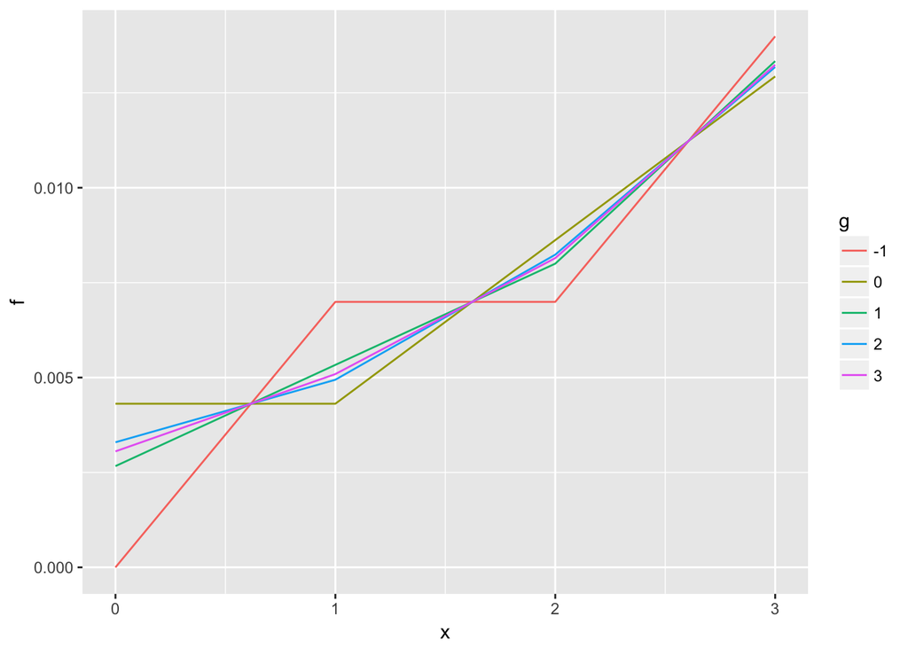

```r
x = 0:3
gs = seq(-1, 3, 0.1)
d = data.frame()
for (g in gs) {
    d = rbind(d, data.frame(x=as.integer(x), g=g, f=Vectorize(F)(x+g)/(Vectorize(F)(g+12) - Vectorize(F)(g+1))))
}
d %<>% mutate(g=as.factor(g))
ggplot(d %>% dplyr::filter(g %in% seq(min(gs),max(gs), 1))) + geom_line(aes(x=x, y=f, color=g))
```

```r
# TODO: hmmm seems like changing gamma has little or no effect on the plots.. Whats going on? Maybe look at the F function more closely?
```

I wanted to demonstrate a few points in this tutorial with a toy example. So here is the task. Given a fixed `gamma` and some data:

First lets look at the STAN code:

```
functions {
    /**
    * Fibonacci series extended to real numbers
    *
    * See eq 10 of http://mathworld.wolfram.com/FibonacciNumber.html
    * but note we want the definition where F(0) = 1 rather than
    * F(0) = 0 so, we have to plug nu + 1 into the function.
    *
    * @param nu Real number greater than -1
    * @param generalized Fibonacci number
    * Courtsey Ben Goodrich, Columbia University
    **/
    real F(real nu) {
        real sqrt_5 = sqrt(5.0); // need 5.0 rather than 5 to avoid error
        real half_sqrt5p1 = 0.5 * (1 + sqrt_5);
        real nu_p1 = nu + 1;
        return (half_sqrt5p1^nu_p1 - half_sqrt5p1^-nu_p1 *
                cos(nu_p1 * pi())) / sqrt_5;
    }
    /**
     * Logarithm of PMF for bowling with real shape parameter, gamma
     *
     * @param x integer(s) between 0 and 10
     * @param gamma real number greater than -1
     * @param n integer(s) between 0 and 10
     * @return log probability of x given gamma and n
     * Courtsey Ben Goodrich, Columbia University
    **/
    real bowling_frame_lpmf(int[] x, real gamma, int[] n) {
        int N = num_elements(x); real out = 0;
        real F_gamma_p1 = F(gamma + 1);
        if (gamma <= -1) reject("gamma must be greater than -1");
        if (num_elements(n) != N)
            reject("number of elements in x and n must match");
        for (i in 1:N) {
            int x_i = x[i];
            real n_i = n[i];
            if (x_i < 0 || x_i > 10)
                reject("all x must be between 0 and 10");
            if (n_i < 0 || n_i > 10)
```

[output cut: 21 more lines]

```
}
// We want a positive gamma
parameters {
   real<lower=0> gamma_p1;
}

transformed parameters {
    real<lower=-1> g = gamma_p1 - 1; // We want gamma - 1
}

model {
   target += gamma_lpdf(gamma_p1|  9, 2); // keeping rate and shape constant for now
   target += bowling_frame_lpmf(x1| g, ninit);
   target += bowling_frame_lpmf(x2| g, n_minus_x1);
}
```

- Kept things simple with the gamma’s rate and shape paramters just constants: 9, 2
- The gamma in the PMF has nothing to do with the gamma distribution. I just chose gamma distribution for this example. I could have chosen anything
- Note the transformed parameters bit. The gamma param from the gamma distribution has to be non negative. But the PMF allows values >= -1 so we transform it.
- Note the use of `target +=` statement. They increment the log probability in exact amounts since we know the normalizing constant in the posterior kernel we take advantage of them.
- TODO: Reference to Stan manual for code.

```r
expose_stan_functions("./bowling.stan")  # Compiles the C++ function and caches it
```

Now time for some fake data.

```r
# Generate some data using sample function
set.seed(100)
npins = 10
omega_x = 0:npins
g.init = rgamma(1, 9, 2)  # just a value for now to generate the frames.
PMF = function(x, g, pins) {
    if (x > pins) {
        return(0)
    }
    F(x + g)/(F(pins + g + 2) - F(g + 1))
}
n = 500  # generate n frames like in a game. Keeping this number high so that we can have more data to play with
x1 = sample(omega_x, size = n, replace = TRUE, prob = sapply(0:npins, function(x) {
    PMF(x, g.init, npins)
}))
# i.e. draw a sample of n rolls, each of which is select from a npins
# Dimension(#pins) vector: p(X=x|g, npins) where x \in [0:npins]. Then for
# the left over pins simulate the left over rolls.
x2 = rep(0, n)
# Sample x2|x1 in the exact same way
for (i in 1:n) {
    # For omega_x
    xi = x1[i]
    if (npins - xi > 0)
        {
            x2[i] = sample(0:(npins - xi), size = 1, prob = sapply(0:(npins -
                xi), function(x) {
                PMF(x, g.init, npins - xi)
            }))
        }  # any balls left?

}
data.list = list(x1 = x1, x2 = x2, nframes = length(x1))
```

### A few things to note

I chose a constant for `g.init`. OTOH I could generate many frames with a different g.init’s coming from some sort of distribution. More on that later. You can recover this distribution’s posterior if you know about it. Many stat models that model real life phenomenon actually generate a distribution over the hyperparams, but that requires a bit more sophisticated(although very instructive) analysis where each roll could have many distributions.

Now learn the model via stan

```r
stan.fit = stan("./bowling.stan", data = data.list, iter = 5000, cores = 4,
    chains = 4, control = list(adapt_delta = 0.98))
```

stan.fit will contain the posterior samples

Lets see how well we recovered the original parameter g.init from the simulation.

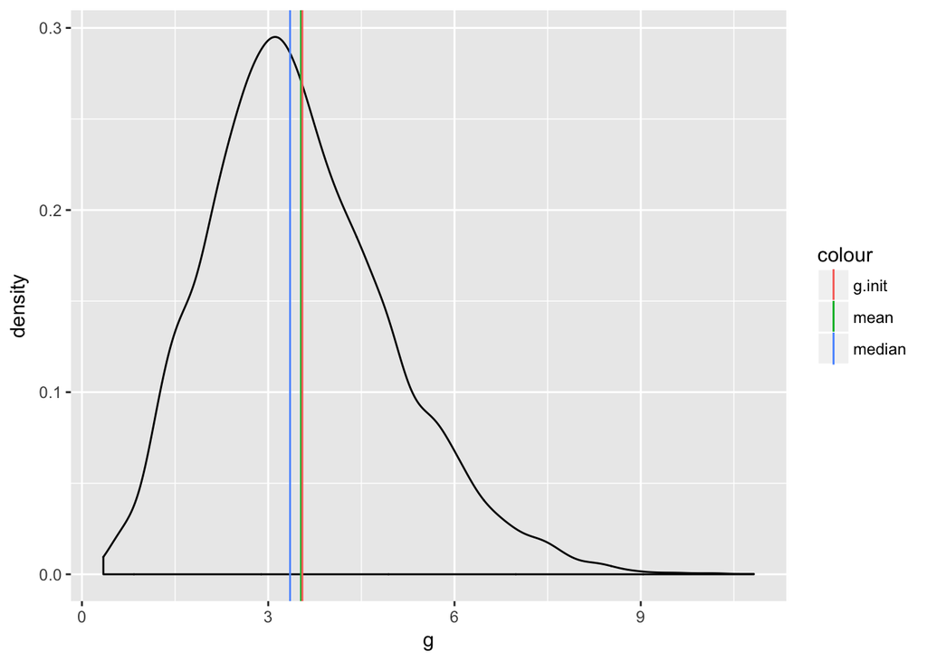

```r
sims = as.data.frame(stan.fit)
# Did we recover the value of gamma?
p1 = ggplot(sims) + geom_density(aes(x = g)) + geom_vline(aes(xintercept = mean(g),
    color = "mean")) + geom_vline(aes(xintercept = median(g), color = "median")) +
    geom_vline(aes(xintercept = g.init, color = "g.init"))
print(p1)
```

The mean, median and the chosen value of g are pretty close. So we are happy. # Generating posterior predictions

```r
n.post.samples = 100 # Choose a 100 samples from the posterior of gamma
gamma.posterior = sims$gamma_p1[1:n.post.samples]

x1.posterior = data.frame(matrix(0, nrow=n.post.samples, ncol=n)) # a frame of bowling per posterior sample
colnames(x1.posterior) = sapply(1:n, function(i) {paste("frame_", i, sep="")})
x2.posterior = data.frame(matrix(0, nrow=n.post.samples, ncol=n))
colnames(x2.posterior) = sapply(1:n, function(i) {paste("frame_", i, sep="")})

#PMF.vectorized = Vectorize(PMF, vectorize.args=c("g", "n"))


# Generate all the frames *per* value of gamma
for(i in 1:n.post.samples) {
    x1.posterior[i, ] = sample(
                             omega_x,
                             size=n,
                             replace=TRUE,
                             prob=sapply(0:npins,
                                         function(x) {
                                             PMF(x, g=gamma.posterior[i], pins=npins)
                                        }))
    leftover.pins = c(t(npins - x1.posterior[i, ])) # convert to vector
    # There is no easy efficient way to sample for x2 because leftover.pins[j] is different for
    # each frame j. There is combinatorially many such values
    for(j in 1:n) {
        x2.posterior[i, j] = sample(
                                0:leftover.pins[j],
                                size=1,
                                prob=sapply(0:leftover.pins[j],
                                            function(x) {
                                                 PMF(x, g=gamma.posterior[i], pins=leftover.pins[j])
                                            })
                                )
    }

}
```

Even with the small domain of X, simulation of posterior samples is computationally intensive because `sample()` function needs to be evaluated for X2|X1 for each posterior sample. The x1’s are more efficient to simulate but once you have more variables in your conditional distribution you just get need to evaluate the density that is polynomial the arity of those variables.

How do these compare to the initial x’s generated

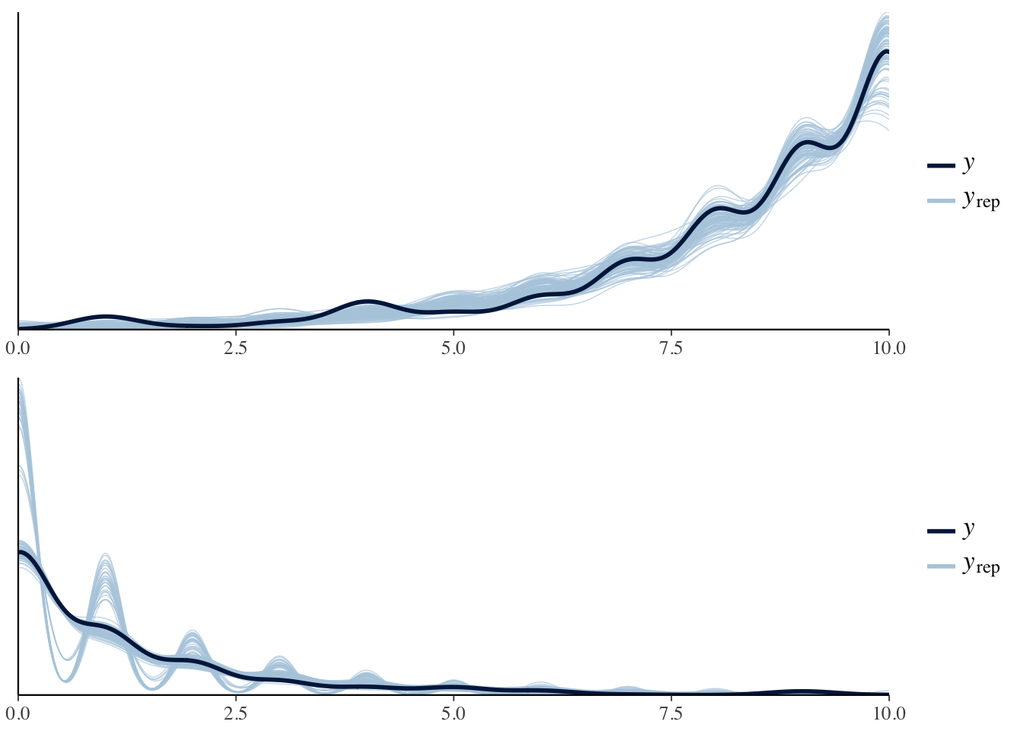